# Principle Component Aanalysis

# Part III

Also in this repository is a data set collected from TC students (tc-program-combos.csv) that shows how many students thought that a TC program was related to andother TC program. Students were shown three program names at a time and were asked which two of the three were most similar. Use PCA to look for components that represent related programs. Explain why you think there are relationships between these programs.

```r
library(ggplot2)
library(GGally)
library(dplyr)
```

```r
DF1 <- read.csv("tc-program-combos.csv", header=TRUE)
DF2 <- DF1[,-1]
```

```r
mypca <- prcomp(DF2, scale = TRUE)
mypca
```

[output not shown]

[output cut: 2272 more lines]

[output not shown]

```r
summary(mypca)
```

```
## Importance of components:
##                           PC1     PC2     PC3     PC4     PC5     PC6     PC7
## Standard deviation     2.6670 2.33303 2.03824 1.80893 1.71451 1.60412 1.58799
## Proportion of Variance 0.1062 0.08124 0.06201 0.04884 0.04387 0.03841 0.03764
## Cumulative Proportion  0.1062 0.18740 0.24941 0.29825 0.34212 0.38053 0.41816
##                            PC8    PC9    PC10    PC11    PC12   PC13    PC14
## Standard deviation     1.49222 1.4642 1.39139 1.33521 1.32517 1.3121 1.26312
## Proportion of Variance 0.03323 0.0320 0.02889 0.02661 0.02621 0.0257 0.02381
## Cumulative Proportion  0.45140 0.4834 0.51229 0.53890 0.56511 0.5908 0.61462
##                           PC15    PC16    PC17    PC18   PC19   PC20   PC21
## Standard deviation     1.25366 1.22339 1.21896 1.18649 1.1313 1.1281 1.1043
## Proportion of Variance 0.02346 0.02234 0.02218 0.02101 0.0191 0.0190 0.0182
## Cumulative Proportion  0.63808 0.66042 0.68260 0.70361 0.7227 0.7417 0.7599
##                           PC22    PC23    PC24    PC25    PC26    PC27    PC28
## Standard deviation     1.06319 1.01168 0.99666 0.96528 0.95049 0.93257 0.90508
## Proportion of Variance 0.01687 0.01528 0.01483 0.01391 0.01348 0.01298 0.01223
## Cumulative Proportion  0.77678 0.79205 0.80688 0.82079 0.83427 0.84725 0.85948
##                           PC29   PC30    PC31    PC32    PC33    PC34   PC35
## Standard deviation     0.85161 0.8348 0.81880 0.78539 0.76079 0.73351 0.7228
## Proportion of Variance 0.01082 0.0104 0.01001 0.00921 0.00864 0.00803 0.0078
## Cumulative Proportion  0.87030 0.8807 0.89071 0.89992 0.90856 0.91659 0.9244
##                           PC36    PC37    PC38    PC39    PC40    PC41    PC42
## Standard deviation     0.67319 0.66343 0.64839 0.62449 0.60331 0.56847 0.55769
## Proportion of Variance 0.00676 0.00657 0.00627 0.00582 0.00543 0.00482 0.00464
## Cumulative Proportion  0.93115 0.93772 0.94399 0.94981 0.95524 0.96007 0.96471
##                           PC43    PC44    PC45    PC46   PC47    PC48    PC49
## Standard deviation     0.51032 0.49443 0.47128 0.44551 0.4329 0.41344 0.37260
## Proportion of Variance 0.00389 0.00365 0.00332 0.00296 0.0028 0.00255 0.00207
## Cumulative Proportion  0.96860 0.97224 0.97556 0.97852 0.9813 0.98387 0.98594
##                           PC50    PC51    PC52    PC53    PC54    PC55    PC56
## Standard deviation     0.36654 0.35016 0.33278 0.32800 0.30414 0.28040 0.27067
## Proportion of Variance 0.00201 0.00183 0.00165 0.00161 0.00138 0.00117 0.00109
## Cumulative Proportion  0.98795 0.98978 0.99143 0.99304 0.99442 0.99559 0.99668
##                           PC57    PC58    PC59    PC60    PC61   PC62    PC63
## Standard deviation     0.23730 0.21156 0.17617 0.16542 0.14778 0.1420 0.11093
## Proportion of Variance 0.00084 0.00067 0.00046 0.00041 0.00033 0.0003 0.00018
## Cumulative Proportion  0.99752 0.99819 0.99866 0.99906 0.99939 0.9997 0.99987
##                           PC64    PC65    PC66    PC67
## Standard deviation     0.07055 0.04430 0.03589 0.01241
## Proportion of Variance 0.00007 0.00003 0.00002 0.00000
## Cumulative Proportion  0.99995 0.99998 1.00000 1.00000
```

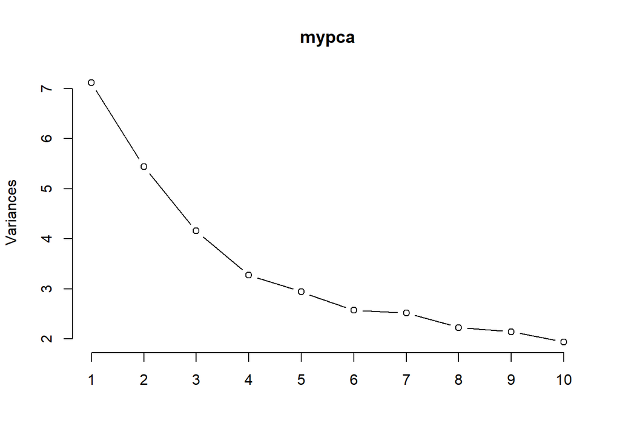

```r
plot(mypca, type = "l")
```

[figure not shown]

```r
biplot(mypca, scale = 0)
```

```r
mypca$x
```

[output not shown]

[output cut: 895 more lines]

[figure not shown]

```r
DF3 <- data.frame(DF1, mypca$x[,c(1:2)])
ggplot(DF3, aes(PC1,PC2, col = program, fill = program)) +
  stat_smooth(geom = "smooth")+
  geom_point(shape = 21, col = "black")
```